# Improving Data Visualization

# 1 Import data

```r
library(openintro)
library(tidyverse)
library(ggplot2)
babies <- babies %>%
  mutate(smoke = as.logical(smoke),
         parity = as.logical(parity))
```

Read documentation for this data set. Try `??babies`

# 2 Scatter plot

Task:

- Using the `babies` data,
- Map `gestation` to x-axis, `bwt` to y-axis, `smoke` to shape and color.
- Add a layer of points and set the size of the points to 4.

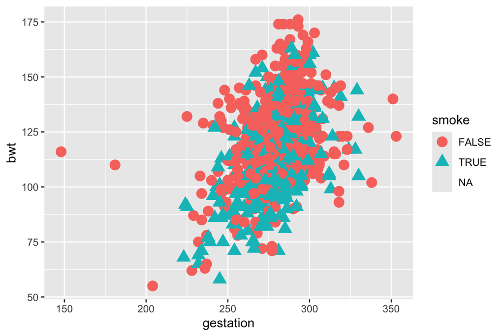

```r
ggplot(babies,
       aes(x = gestation,
           y = bwt,
           shape = smoke,
           color = smoke)) +
  geom_point(size = 4)
```

# 3 Add labels to axis using `labs()`

Task:

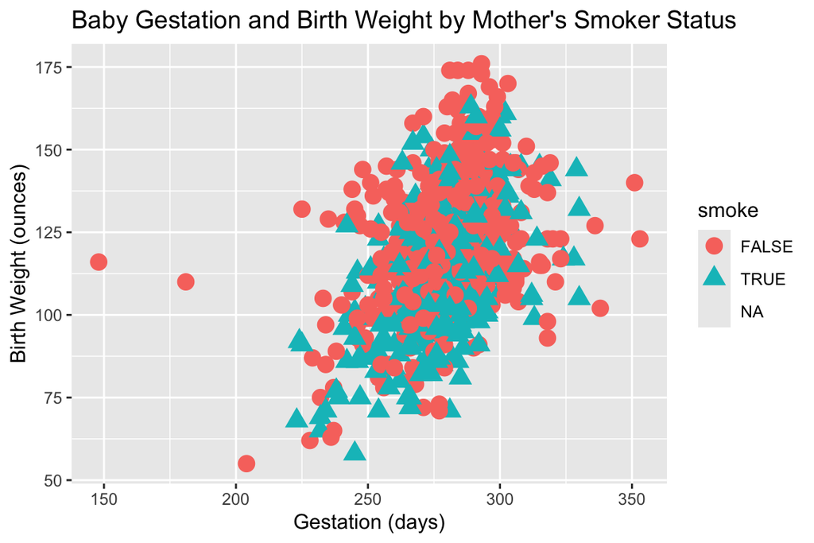

```r
ggplot(babies,
       aes(x = gestation,
           y = bwt,
           shape = smoke,
           color = smoke)) +
  geom_point(size = 4) +
  labs(x = "Gestation (days)", #<<
       y = "Birth Weight (ounces)", #<<
       title = "Baby Gestation and Birth Weight by Mother's Smoker Status") #<<
```

# 4 Themes

## 4.1 Theme options:

Let’s customize the theme. Try add a layer of `theme_bw()`.

Other theme options:

- `theme_gray()`
- `theme_bw()`
- `theme_classic()`
- `theme_dark()`
- `theme_minimal()`
- `theme_void()`

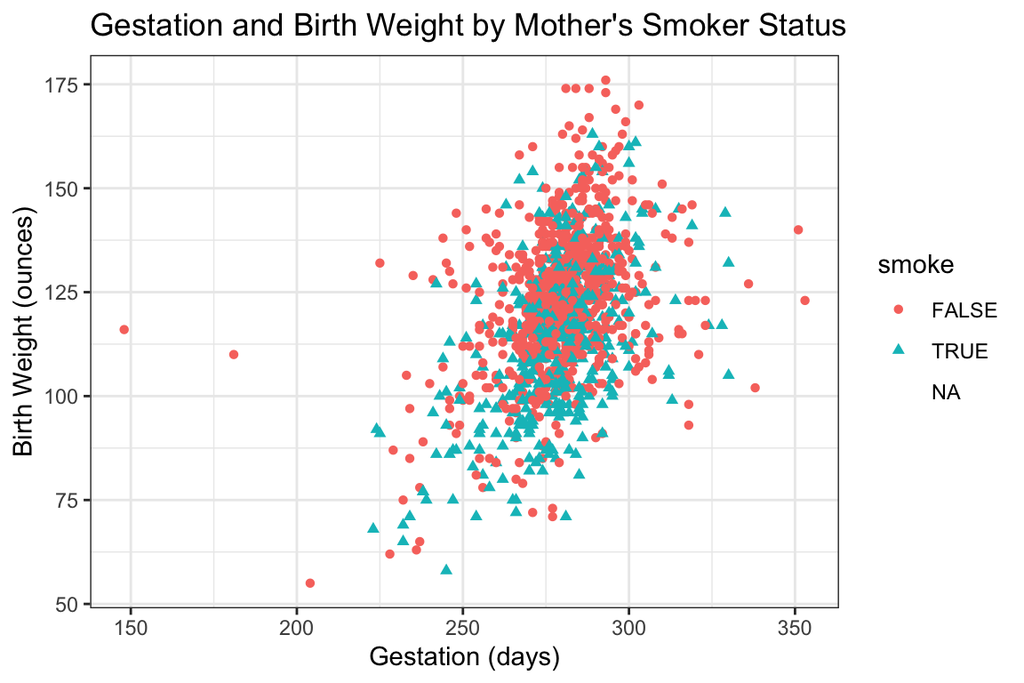

```r
ggplot(babies,
       aes(x = gestation,
           y = bwt,
           shape = smoke,
           color = smoke)) +
  geom_point() +
labs(x = "Gestation (days)",
       y = "Birth Weight (ounces)",
       title = "Gestation and Birth Weight by Mother's Smoker Status") +
  theme_bw() #<<
```

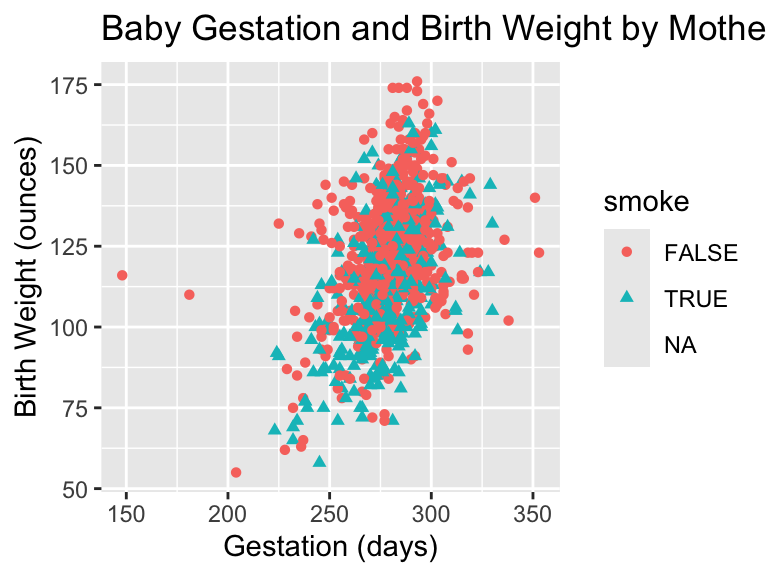

```r
ggplot(babies,
       aes(x = gestation,
           y = bwt,
           shape = smoke,
           color = smoke)) +
  geom_point() +
  labs(x = "Gestation (days)",
       y = "Birth Weight (ounces)",
       title = "Baby Gestation and Birth Weight by Mother's Smoker Status") +
  theme_gray()
```

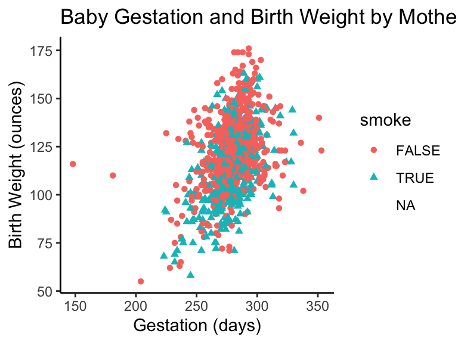

```r
ggplot(babies,
       aes(x = gestation,
           y = bwt,
           shape = smoke,
           color = smoke)) +
  geom_point() +
  labs(x = "Gestation (days)",
       y = "Birth Weight (ounces)",
       title = "Baby Gestation and Birth Weight by Mother's Smoker Status") +
  theme_classic()
```

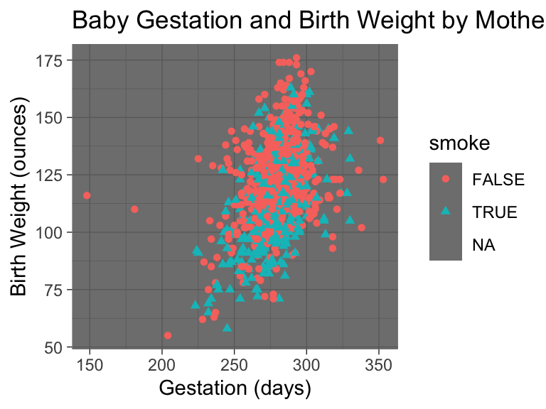

```r
ggplot(babies,
       aes(x = gestation,
           y = bwt,
           shape = smoke,
           color = smoke)) +
  geom_point() +
  labs(x = "Gestation (days)",
       y = "Birth Weight (ounces)",
       title = "Baby Gestation and Birth Weight by Mother's Smoker Status") +
  theme_dark()
```

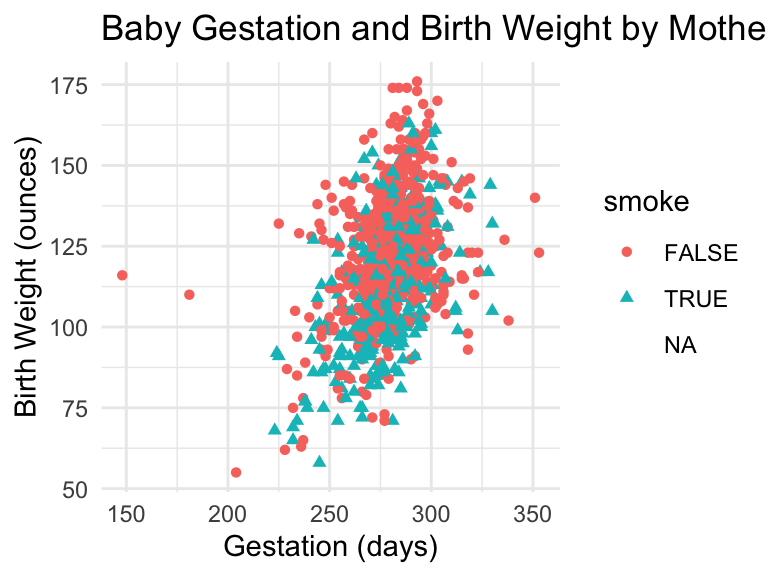

```r
ggplot(babies,
       aes(x = gestation,
           y = bwt,
           shape = smoke,
           color = smoke)) +
  geom_point() +
  labs(x = "Gestation (days)",
       y = "Birth Weight (ounces)",
       title = "Baby Gestation and Birth Weight by Mother's Smoker Status") +
  theme_minimal()
```

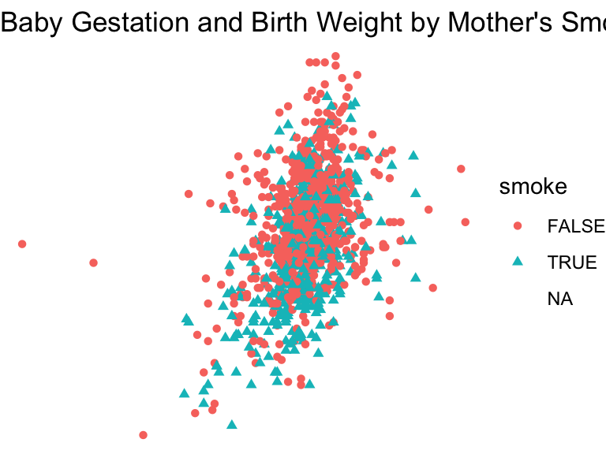

```r
ggplot(babies,
       aes(x = gestation,
           y = bwt,
           shape = smoke,
           color = smoke)) +
  geom_point() +
  labs(x = "Gestation (days)",
       y = "Birth Weight (ounces)",
       title = "Baby Gestation and Birth Weight by Mother's Smoker Status") +
  theme_void()
```

## 4.2 Explore `theme()`

```r
?theme
```

There are more aspects of a theme that we can control.

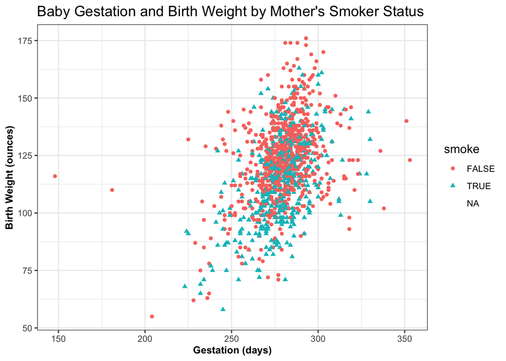

```r
ggplot(babies,
       aes(x = gestation,
           y = bwt,
           shape = smoke,
           color = smoke)) +
  geom_point() +
  labs(x = "Gestation (days)",
       y = "Birth Weight (ounces)",
       title = "Baby Gestation and Birth Weight by Mother's Smoker Status") +
  theme_bw() +
  theme(title =
          element_text(size = 12),
        axis.title =
          element_text(size = 10,
                       face="bold"))
```

# 5 Layout panels in a grid

`facet_grid()` splits your plot into a grid of panels — one panel per group — so you can compare patterns across categories side by side. The formula `rows ~ cols` controls the direction: `.~var` places panels side by side in columns, while `var~.` stacks them in rows.

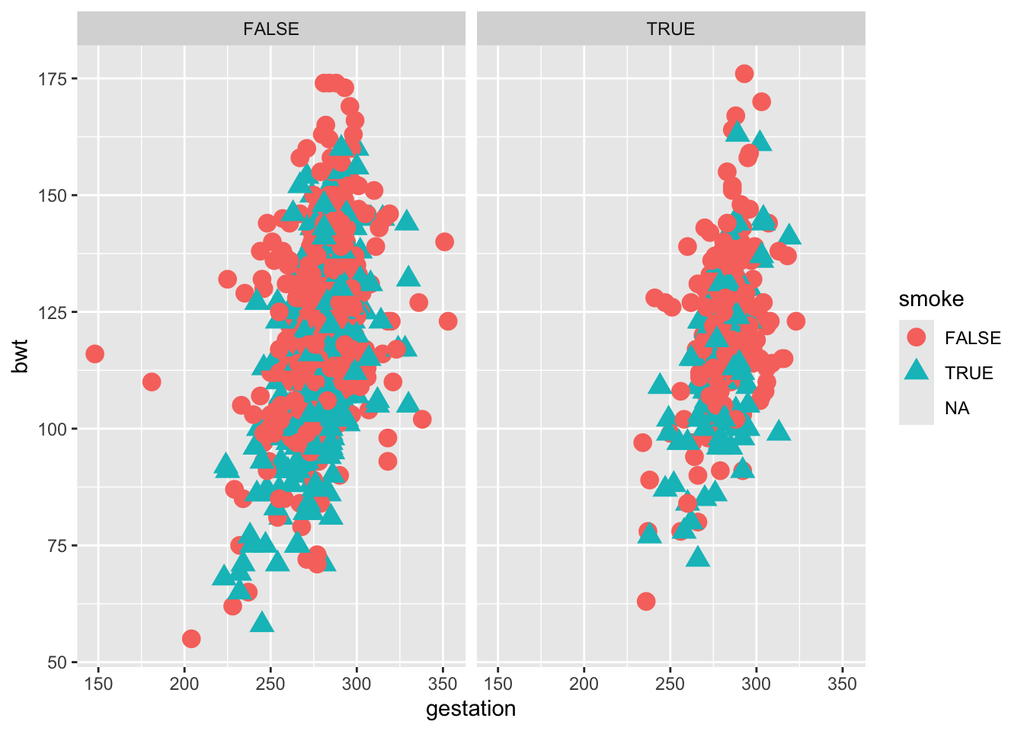

```r
ggplot(babies,
       aes(x = gestation,
           y = bwt,
           shape = smoke,
           color = smoke)) +
  geom_point(size = 4) +
  facet_grid(.~parity) #<<
```

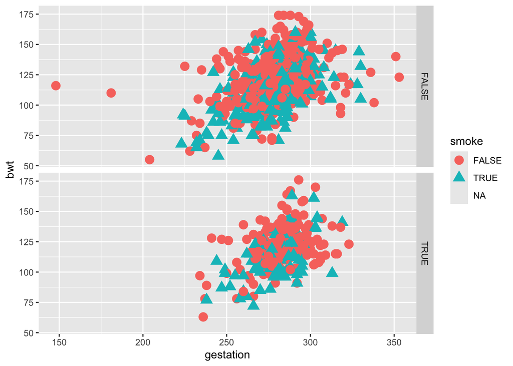

```r
ggplot(babies,
       aes(x = gestation,
           y = bwt,
           shape = smoke,
           color = smoke)) +
  geom_point(size = 4) +
  facet_grid(parity~.) #<<
```

# 6 Summary

You can do much more in ggplot.

- Use images
- Make maps
- Pick colors that you want,

Resources:

- [the ggplot flipbook](https://evamaerey.github.io/ggplot_flipbook/ggplot_flipbook_xaringan.html#1)
- [coloring for colorblindness](https://davidmathlogic.com/colorblind/#%23D81B60-%231E88E5-%23FFC107-%23004D40)
- [Gallery](https://r-graph-gallery.com/ggplot2-package.html)
- [BBC](https://bbc.github.io/rcookbook/)
- [fivethirtyeight](https://blog.revolutionanalytics.com/2016/07/data-journalism-with-r-at-538.html?utm_content=bufferc03e0&utm_medium=social&utm_source=twitter.com&utm_campaign=buffer)
- [NY Times](https://livefreeordichotomize.com/2021/04/07/nytimes-map-how-to/)

# 7 Practice

Can you make this plot?

## 7.1 Relationship between smoke mother v.s. birth weight

**Hint**: use `filter()` and `is.na()` to remove the NA values in the smoke column

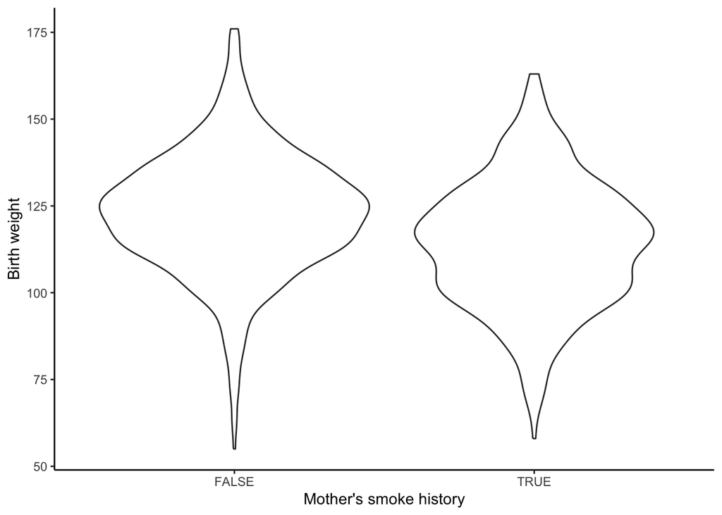

```r
babies %>%
  filter(!is.na(smoke)) %>%
  ggplot(
       aes(x = smoke,
           y = bwt)) +
  geom_violin() +
  labs(x = 'Mother\'s smoke history', y = 'Birth weight')+
  theme_classic()
```

## 7.2 Relationship between mother’s age group v.s. birth weight

**Hint**: use `case_when()` to create a new variable `age_group` and use `geom_jitter()` and `geom_boxplot()` to make this figure!

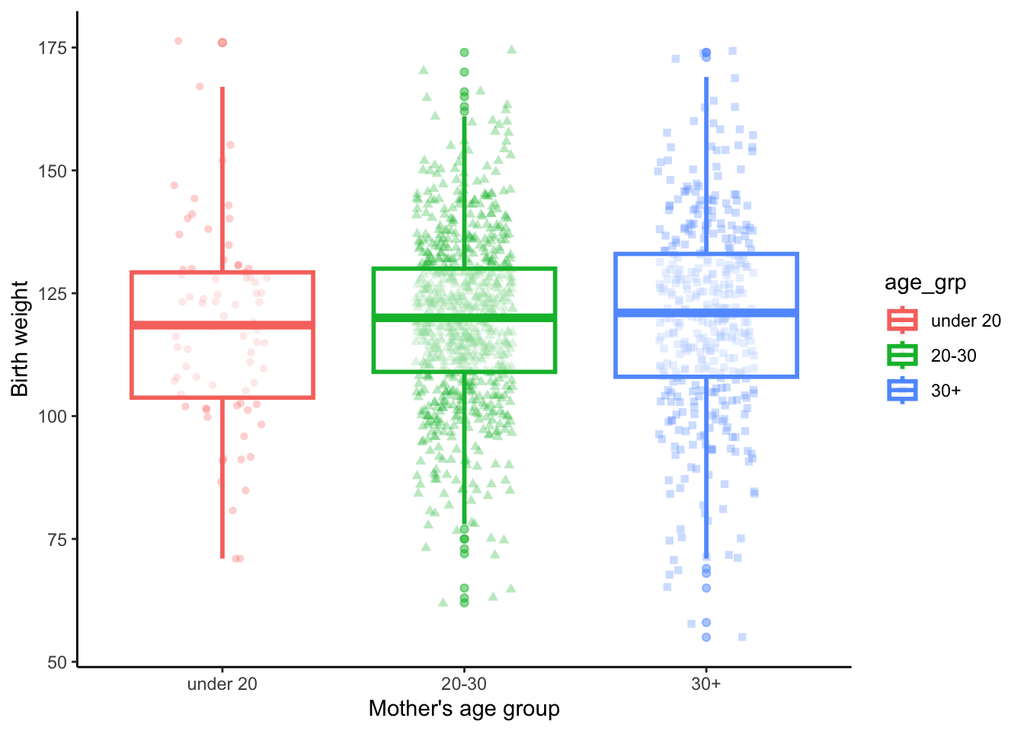

```r
babies %>%
  mutate(
    age_grp = case_when(
      age >= 30 ~ '30+',
      20 <= age & age < 30 ~ '20-30',
      age < 20 ~ 'under 20'
    ),
    age_grp = factor(age_grp, levels = c('under 20','20-30','30+'))
  ) %>%
  filter(!is.na(age_grp)) %>%
  ggplot(aes(
    x = age_grp,
           y = bwt,
           shape = age_grp,
           color = age_grp)) +
  geom_jitter(width = 0.2,alpha = 0.3) +
  geom_boxplot(alpha = 0.5, size = 1) +
  labs(x = 'Mother\'s age group', y = 'Birth weight')+
  theme_classic()
```